# Calibrating & Simulating Natural Gas Spot Prices

This example demonstrates calibrating an Ornstein-Uhlenbeck mean reverting stochastic model from historical data of natural gas prices. The model is then used to simulate the spot prices into the future using the Stochastic Differential Equation Simulation engine in Econometrics Toolbox.

Table of Contents

Import Historical Data The Model Calibrate Parameters Create an Ornstein-Uhlenbeck mean reverting drift model Monte-Carlo Simulation Save Model Visual Analysis of Simulated Price Paths Automated Visualization for Calibration Report

## Import Historical Data

```matlab
clearvars
load Data\ngPrices.mat
tail(ngPrices)
```

ans = 8×5 timetable

|  | RNGWHHDd | RNGC1d | RNGC2d | RNGC3d | RNGC4d |
| --- | --- | --- | --- | --- | --- |
| 1 04-Jan-2019 00:00:00 | 2.8000 | 3.0440 | 2.9050 | 2.6880 | 2.6600 |
| 2 07-Jan-2019 00:00:00 | 2.7400 | 2.9440 | 2.8470 | 2.6770 | 2.6620 |
| 3 08-Jan-2019 00:00:00 | 2.8900 | 2.9670 | 2.8350 | 2.6950 | 2.6830 |
| 4 09-Jan-2019 00:00:00 | 2.9200 | 2.9840 | 2.8400 | 2.7060 | 2.6960 |
| 5 10-Jan-2019 00:00:00 | 2.9500 | 2.9690 | 2.8130 | 2.7060 | 2.6980 |
| 6 11-Jan-2019 00:00:00 | 2.9500 | 3.0990 | 2.9450 | 2.7690 | 2.7470 |
| 7 14-Jan-2019 00:00:00 | 3.3600 | 3.5910 | 3.2890 | 2.9050 | 2.8620 |
| 8 15-Jan-2019 00:00:00 | NaN | 3.5010 | 3.2490 | 2.8460 | 2.8040 |

Note that there are missing values in the data set, such as above. We will fill the missing values with the previously observed price and then remove the remining missing data set at the head of the table.

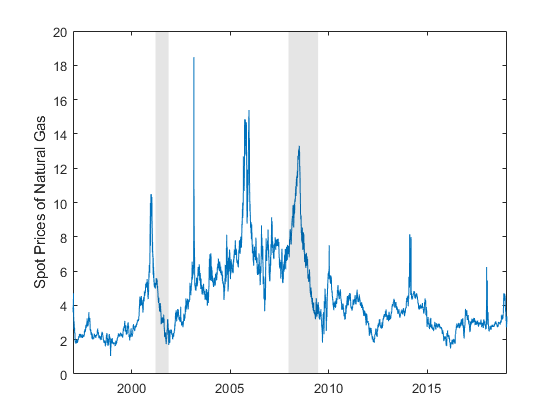

```matlab
ngPrices = fillmissing(ngPrices,'previous'); % enough data to fill
ngPrices = rmmissing(ngPrices); % remove remaining missing data
Dates = ngPrices.Time;
S = ngPrices.RNGWHHDd;

plot(Dates,S)
ylabel('Spot Prices of Natural Gas')
recessionplot
```

## The Model

The model used for simulating the Natural Gas prices is an Ornstein-Uhlenbeck brownian motion with mean reverting drift. This model is fit to the log of natural gas prices. The discrete-time equation of this model can be written as,

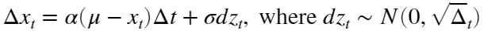

## Calibrate Parameters

The reversion rate and mean level can be calculated from the coefficients of a linear fit between the log prices and their first difference scaled by the time interval parameter. All quantities are specified on an annual scale.

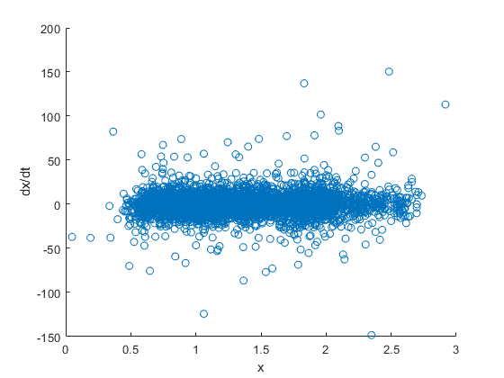

```matlab
x = log(S);
dx = diff(x);
dt = 1/261; % Time in years (261 observations per year)
dxdt = dx/dt;
x(1) = []; % To ensure the number of elements in x and dxdt match

scatter(x,dxdt)
xlabel('x')
ylabel('dx/dt')
```

Fit a linear trend to estimate mean reversion parameters

```matlab
mdl = fitlm(x, dxdt,'linear','VarNames',{'dxdt','x'})
```

mdl =

Linear regression model: x ~ 1 + dxdt Estimated Coefficients: **Estimate** **SE** **tStat** **pValue** **________** **_______** **_______** **__________** **(Intercept)** -1.7261 0.49313 -3.5003 0.00046839 **dxdt** 1.2665 0.34403 3.6814 0.00023413 Number of observations: 5564, Error degrees of freedom: 5562 Root Mean Squared Error: 11.8 R-squared: 0.00243, Adjusted R-Squared 0.00225 F-statistic vs. constant model: 13.6, p-value = 0.000234

```matlab
revRate   = -mdl.Coefficients.Estimate(1)
```

revRate = 1.7261

```matlab
meanLevel = mdl.Coefficients.Estimate(2)/revRate
```

meanLevel = 0.7337

```matlab
res = dxdt - predict(mdl,x);
vol = std(res) * sqrt(dt)
```

vol = 0.7281

## Create an Ornstein-Uhlenbeck mean reverting drift model

An Ornstein-Uhlenbeck model is a special case of a Hull-White-Vasicek model with constant volatility. The HWV constructor is used to setup an SDE model with the parameters estimated above. The start state of the model is set to the last observed log spot price. This model can be easily extend to accommodate the forward curve and option prices by setting the meanLevel and volatility parameters to be functions of time.

```matlab
OUmodel = hwv(revRate, meanLevel, vol,  'StartState', x(end))
```

OUmodel =

Class HWV: Hull-White/Vasicek ---------------------------------------- Dimensions: State = 1, Brownian = 1 ---------------------------------------- StartTime: 0 StartState: 1.21194 Correlation: 1 Drift: drift rate function F(t,X(t)) Diffusion: diffusion rate function G(t,X(t)) Simulation: simulation method/function simByEuler Sigma: 0.728094 Level: 0.733742 Speed: 1.7261

Alternatively, one could equivalently use the SDEMRD object as follows

```matlab
OUmodelSDE = sdemrd(revRate, meanLevel, 0, vol, 'StartState', x(end))
```

OUmodelSDE =

Class SDEMRD: SDE with Mean-Reverting Drift ------------------------------------------- Dimensions: State = 1, Brownian = 1 ------------------------------------------- StartTime: 0 StartState: 1.21194 Correlation: 1 Drift: drift rate function F(t,X(t)) Diffusion: diffusion rate function G(t,X(t)) Simulation: simulation method/function simByEuler Alpha: 0 Sigma: 0.728094 Level: 0.733742 Speed: 1.7261

## Monte-Carlo Simulation

The model defined above can be simulated with the simulate method of the SDE object to generate multiple log price paths. These are exponentiated to compute the simulated natural gas prices. The plot below shows 100 paths simulated 80 days into the future.

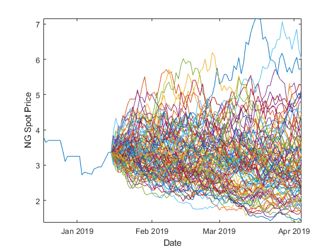

```matlab
NTrials = 1000;
NSteps  = 2000;

Xsim = simulate(OUmodel, NSteps, 'NTrials', NTrials, 'DeltaTime', dt);
Xsim = squeeze(Xsim); % Remove redundant dimension
Ssim = exp(Xsim);

% This does the same as the lines above, but puts it all in a function we
% can reuse for different NTrials, and NSteps.  We will use this later.
simFcn = @(NSteps, NTrials) exp( squeeze( simulate(OUmodel, NSteps, 'NTrials', NTrials, 'DeltaTime', dt) ) );

% Visualize first 80 prices of 100 paths
plot(Dates(end-20:end), S(end-20:end), Dates(end)+days(0:79), Ssim(1:80,1:100));
xlabel('Date')
ylabel('NG Spot Price')
axis tight
```

## Save Model

The calibrated model is saved in a MAT-file for later use.

```matlab
mkdir SavedModels
```

Warning: Directory already exists.

```matlab
ngModel = struct('oumodel',OUmodel,'dt',dt,'simFcn',simFcn,'lastDate',Dates(end),'Freq','daily','Data',timetable(Dates,S))
```

ngModel = struct with fields:

oumodel: [1×1 hwv] dt: 0.0038 simFcn: @(NSteps,NTrials)exp(squeeze(simulate(OUmodel,NSteps,'NTrials',NTrials,'DeltaTime',dt))) lastDate: 15-Jan-2019 00:00:00 Freq: 'daily' Data: [5565×1 timetable]

```matlab
save SavedModels\NGPriceModel.mat -struct ngModel
```

## Visual Analysis of Simulated Price Paths

Instead of plotting a number of paths at once, we can plot longer single paths against the observed historical data to visually validate the simulated paths. This can serve as a final sanity check.

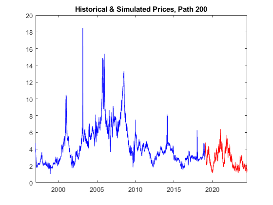

```matlab
path = 200;
plot(Dates, S, 'b', Dates(end)+days(0:NSteps), Ssim(:,path), 'r');
title(['Historical & Simulated Prices, Path ' int2str(path)]);
```

## Automated Visualization for Calibration Report

This section creates plots of different simulations in an automated fashion to include in the calibration report.

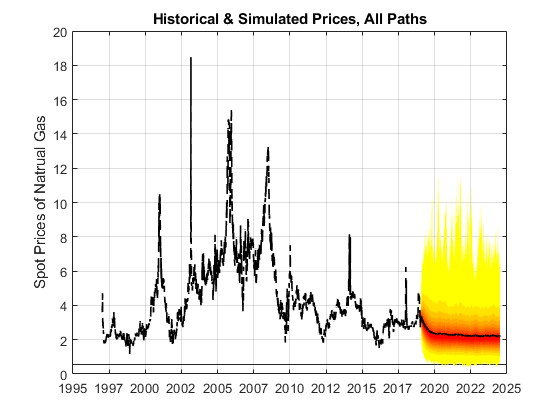

```matlab
NTrials = 1000;
NSteps  = 2000;
Ssim = simFcn(NSteps, NTrials);

fanplot(table(Dates, S), [table(Dates(end)+days(0:NSteps)','VariableName',{'Dates'}),array2table(Ssim)], 'HistoricalMarker','none');
ylabel('Spot Prices of Natrual Gas')
title('Historical & Simulated Prices, All Paths');
```

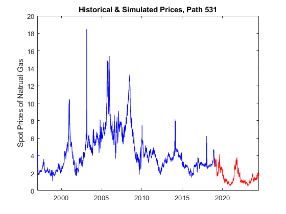

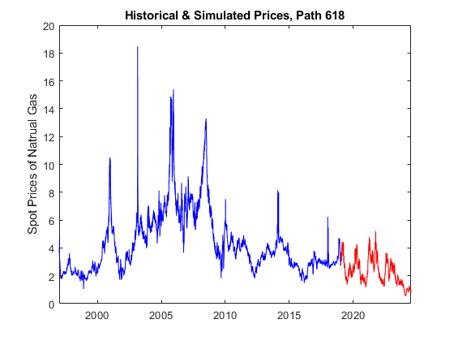

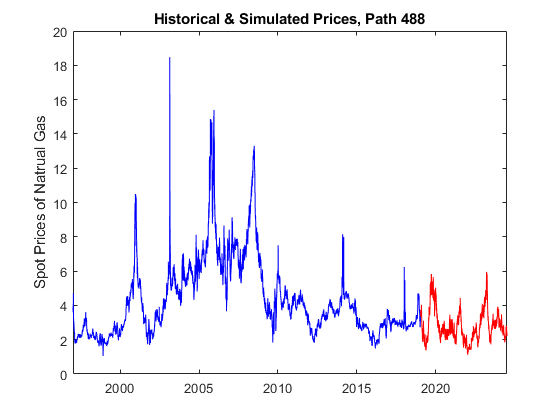

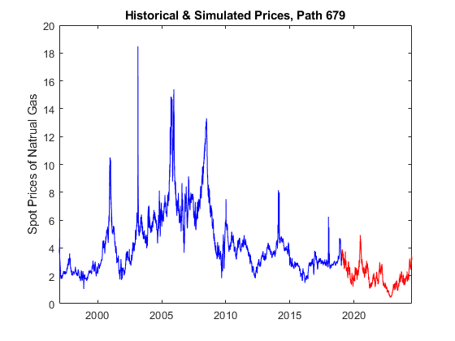

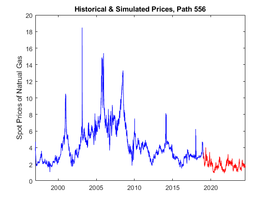

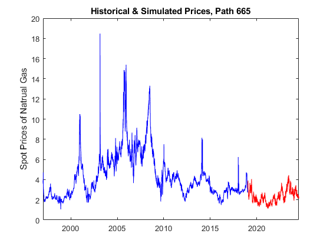

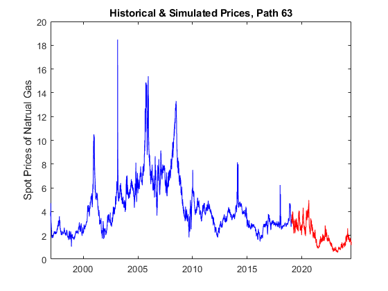

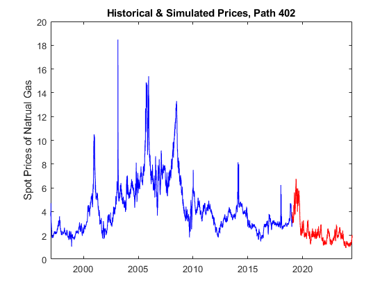

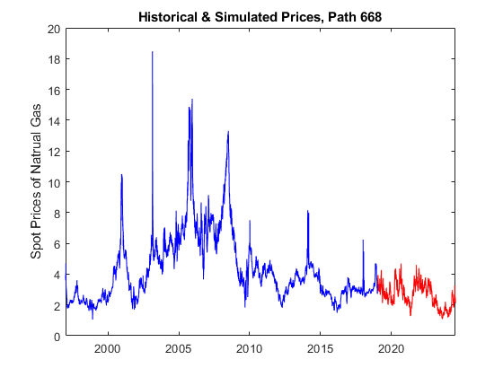

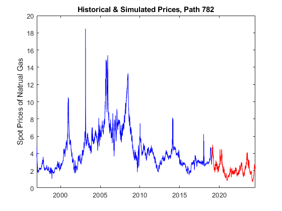

```matlab
% Show 10 random paths from the simulation
for path = randi(NTrials,[1,10])
    figure
    plot(Dates, S, 'b', Dates(end)+(0:NSteps), Ssim(:,path), 'r');
    ylabel('Spot Prices of Natrual Gas')
    title(['Historical & Simulated Prices, Path ' int2str(path)]);
    snapnow;
end
```